# L04 Performance Metrics

#### Qa Implement the Accuracy function and test it on the MNIST data.

Implement a general accuracy function `MyAccuracy(y_true, y_pred)`. The accuracy is calculated using the formular:

$\begin{array}{rl} a &= \myfrac{TP + TN}{TP + TN + FP + FN} \end{array}$

Where

TP is the True Positive ie. the number of cases that is both prediced positive and actually is positive

TN is the True Negative ie. the number of cases that is prediced negative and actually is negative

FP is the False positive ie. the number of cases that is prediced positive but actually is negative

FN is the False negative ie. the number of cases that is prediced negative but actually is positive

In the case that the denominator is zero, 0.0 is returned.

The accuracy of the '5/not-5' ground-truth data, is compared with the acutal value from `sklearn.metrics.accuracy_score()`, these are the same.

```python
import numpy as np
from sklearn.metrics import accuracy_score
from sklearn.linear_model import SGDClassifier
from sklearn.datasets import fetch_openml
import matplotlib
import matplotlib.pyplot as plt

def MyAccuracy(y_true, y_pred):
    y_true = np.array(y_true)
    y_pred = np.array(y_pred)

    # Calculate components
    TP = np.sum((y_pred == True)  & (y_true == True))
    FN = np.sum((y_pred == False) & (y_true == True))
    FP = np.sum((y_pred == True)  & (y_true == False))
    TN = np.sum((y_pred == False) & (y_true == False))

    # Handle the zero-division case mentioned in the exercise
    denominator = (TP + FN + FP + TN)
    if denominator == 0:
        return 0.0

    acc = (TP + TN) / denominator
    return acc

# TEST FUNCTION: example of a comperator, using Scikit-learn accuracy_score
def TestAccuracy(y_true, y_pred):
   a0=MyAccuracy(y_true, y_pred)
   a1=accuracy_score(y_true, y_pred)

   print(f"\nmy a          ={a0}")
   print(f"scikit-learn a={a1}")

def MNIST_GetDataSet():
    X, y = fetch_openml('mnist_784', return_X_y=True, as_frame=False, cache=True)
    # return_X_y=True: Returns (data, target) instead of a dictionary
    # as_frame=False: Returns data as Numpy arrays
    # cache=True: Saves data locally to avoid re-downloading

    # Convert labels from str. to int.
    y = y.astype(np.int8)

    return X, y

X, y = MNIST_GetDataSet()
print(f"X.shape={X.shape}")
if X.ndim==3:
    print("reshaping X..")
    assert y.ndim==1
    X = X.reshape((X.shape[0],X.shape[1]*X.shape[2]))
assert X.ndim==2
print(f"X.shape={X.shape}")

train_index=50000
X_train, X_test, y_train, y_test = X[:train_index], X[train_index:], y[:train_index], y[train_index:]
y_train_5 = (y_train == 5) # Use integer 5
y_test_5  = (y_test == 5)

sgd_clf = SGDClassifier(random_state=42)
sgd_clf.fit(X_train, y_train_5)

# Get predictions for the test set
y_pred = sgd_clf.predict(X_test)

TestAccuracy(y_test_5, y_pred)
```

```
X.shape=(70000, 784)
X.shape=(70000, 784)

my a          =0.95505
scikit-learn a=0.95505
```

To implement the `MyPrecision`, `MyRecall` and `MyF1Score` functions, use the following formulars:

Precision: $\begin{array}{rl} p &= \myfrac{TP}{TP + FP} \end{array}$

Recall $\begin{array}{rl} r &= \myfrac{TP}{TP + FN} \end{array}$

$F_1$-score $\begin{array}{rl} F_1 &= \myfrac{2pr}{p+r} \end{array}$

In the case that the denominator is zero, 0.0 is returned.

```python
# Qb
from sklearn.metrics import precision_score
from sklearn.metrics import recall_score
from sklearn.metrics import f1_score

def MyPrecision(y_true, y_pred):
    # Ensure inputs are numpy arrays
    y_true = np.array(y_true)
    y_pred = np.array(y_pred)

    # Calculate components
    TP = np.sum((y_pred == True)  & (y_true == True))
    FN = np.sum((y_pred == False) & (y_true == True))
    FP = np.sum((y_pred == True)  & (y_true == False))
    TN = np.sum((y_pred == False) & (y_true == False))

    # Handle the zero-division case
    denominator = (TP + FP)
    if denominator == 0:
        return 0.0
    p = TP / denominator
    return p

def MyRecall(y_true, y_pred):
    # Ensure inputs are numpy arrays
    y_true = np.array(y_true)
    y_pred = np.array(y_pred)

    # Calculate components
    TP = np.sum((y_pred == True)  & (y_true == True))
    FN = np.sum((y_pred == False) & (y_true == True))
    FP = np.sum((y_pred == True)  & (y_true == False))
    TN = np.sum((y_pred == False) & (y_true == False))

    # Handle the zero-division case
    denominator = (TP + FN)
    if denominator == 0:
        return 0.0
    r = TP / (TP + FN)
    return r

def MyF1Score(y_true, y_pred):
    p=MyPrecision(y_true, y_pred)
    r=MyRecall(y_true, y_pred)

    # Handle the zero-division case
    denominator = (p+r)
    if denominator == 0:
        return 0.0
    F1=2*p*r / denominator
    return F1

# TEST FUNCTION: example of a comperator, using Scikit-learn accuracy_score
def TestPrecision(y_true, y_pred):
   p0=MyPrecision(y_true, y_pred)
   p1=precision_score(y_true, y_pred)

   print(f"\nmy p          ={p0}")
   print(f"scikit-learn p={p1}")

def TestRecall(y_true, y_pred):
   r0=MyRecall(y_true, y_pred)
   r1=recall_score(y_true, y_pred)

   print(f"\nmy r          ={r0}")
   print(f"scikit-learn r={r1}")

def TestF1Score(y_true, y_pred):
   F1_0=MyF1Score(y_true, y_pred)
   F1_1=f1_score(y_true, y_pred)

   print(f"\nmy F1          ={F1_0}")
   print(f"scikit-learn F1={F1_1}")

TestPrecision(y_test_5, y_pred)
TestRecall(y_test_5, y_pred)
TestF1Score(y_test_5, y_pred)
```

```
my p          =0.7123479887745556
scikit-learn p=0.7123479887745556

my r          =0.8428334255672385
scikit-learn r=0.8428334255672385

my F1          =0.7721166032953105
scikit-learn F1=0.7721166032953105
```

#### Qc The Confusion Matrix

Generating the confusion matrix for both the Dummy and the SGD classifier using the `scklearn.metrics.confusion_matrix` function.

The Scikit-learn confusion matrix organized like this:

```
scklearnconf=[[TN     FP]
              [FN     TP]]
```

If the parameter calling is wrong (see under) the confusion matrix would be transposed.

Wrong:

```
confusion_matrix(y_test_5_pred, y_test5)
```

Correct:

```
confusion_matrix(y_test_5, y_test_5_pred)
```

```python
# Qc
from sklearn.metrics import confusion_matrix
from sklearn.base import BaseEstimator
from sklearn.linear_model import SGDClassifier

class DummyClassifier(BaseEstimator):
    def fit(self, X, y=None):
        return self # Standard practice to return self

    def predict(self, X):
        # Change (len(X), 1) to just (len(X),) to make it 1D
        return np.zeros(len(X), dtype=bool)

# Instantiate and predict for dnmmy
never_5_clf = DummyClassifier()
y_never_5_pred = never_5_clf.predict(X_test)

# Generate Matrix for dummy
conf_matrix = confusion_matrix(y_test_5, y_never_5_pred)
print("Confusion Matrix for Dummy Classifier:")
print(conf_matrix)

# Instantiate, fit and predict the model
sgd_clf = SGDClassifier(random_state=42)
sgd_clf.fit(X_train, y_train_5)
y_sgd_pred = sgd_clf.predict(X_test)

# Generate Confusion Matrix for SGD
M_SGD = confusion_matrix(y_test_5, y_sgd_pred)
print("Confusion Matrix for SGD Classifier:")
print(M_SGD)
```

```
Confusion Matrix for Dummy Classifier:
[[18193     0]
 [ 1807     0]]
Confusion Matrix for SGD Classifier:
[[17578   615]
 [  284  1523]]
```

#### Qd A Confusion Matrix Heat-map

Generating a *heat map* image for the confusion matrices, `M_dummy` and `M_SGD` respectively, by plotting the confusion matrix and overlaying the respective number of instants.

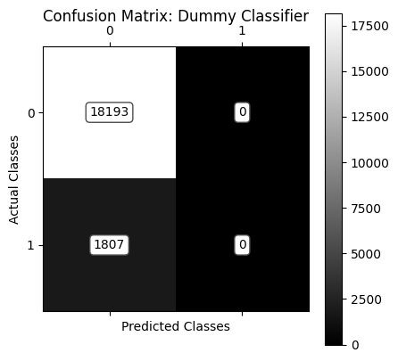

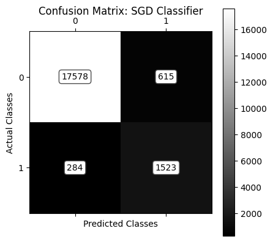

```python
import matplotlib.pyplot as plt
from sklearn.metrics import confusion_matrix

M_dummy = confusion_matrix(y_test_5, y_never_5_pred)
M_SGD = confusion_matrix(y_test_5, y_sgd_pred)

def plot_confusion_matrix(matrix, title):
    # matshow displays an array as a matrix
    plt.matshow(matrix, cmap=plt.cm.gray)
    plt.title(title, pad=20)
    plt.colorbar()
    plt.ylabel('Actual Classes')
    plt.xlabel('Predicted Classes')

    # Overlaying number of instants
    for (i, j), z in np.ndenumerate(matrix):
        plt.text(j, i, '{:d}'.format(z), ha='center', va='center',
                 bbox=dict(boxstyle='round', facecolor='white', edgecolor='0.3'))

    plt.show()

# Plotting
plot_confusion_matrix(M_dummy, "Confusion Matrix: Dummy Classifier")
plot_confusion_matrix(M_SGD, "Confusion Matrix: SGD Classifier")
```

### Qe Conclusion

The essence of these exercises lies in dismantling the illusion that Accuracy is a sufficient metric for evaluating machine learning models. By implementing a "Dummy Classifier" that achieves ~90% accuracy while failing to identify a single actual digit '5', we exposed the Accuracy Paradox. This demonstrated why accuracy is dangerously misleading in imbalanced datasets.

Through the manual implementation of MyAccuracy and the generation of Confusion Matrices, focus shifted from a single percentage to the four outcomes: TP, TN, FP, and FN. The learning outcome was the realization that a model’s value depends on the balance between Precision (avoiding false alarms) and Recall (avoiding missed detections). Visualizing these via Heat-maps further reinforced how to perform "Error Analysis" to see exactly where a model fails. Ultimately, we learned that selecting the right performance metric is very important and often several matrics could be used.